# INTRODUCTION TO GGPLOT2: AESTHETICS

### 2.6 Aesthetics best practices

How do we choose the right visual aesthetics? There is creativity involved, but there are also helpful guidelines.

- Form follows function:

The best data viz serves a purpose, which depends on your audience. First and foremost, the function is the accurate and efficient representation of data. Visual appealing is the secondary priority. The function is never to misrepresent or obscure the data. We can avoided this by always considering the intended audience and purpose of the plots.

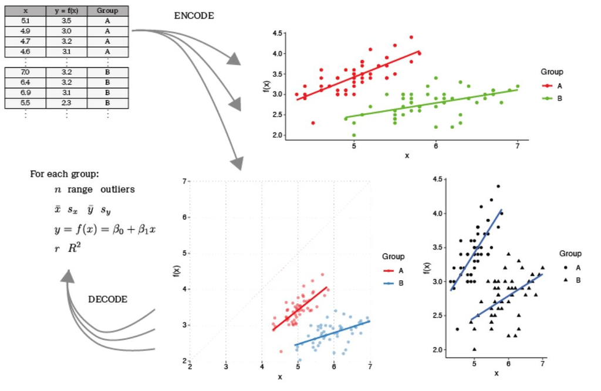

For example, we have two continuous variables in the dataset, x and y. y is the function of x. There are two groups: A and B. It is pretty difficult to obtain summary just by looking at the data. We have two choices: numeric summaries which are precise but offer a poor overview, or data visualization, which is less precise but great for overviews. To make a plot, we encode data in numbers and text into a visual medium (aesthetic mapping). These visuals are then decoded to form an image of th original data. This process is inherently imprecise, similarly to translating between two languages.

The best choices for aesthetics are those which are both efficient, in that they are faster than numeric summaries, and accurate, in that they minimize this information loss.

The choice of aesthetic mapping depends on the type of variable. The scatter plot is so easy to understand because it maps data as position on a common scale.

```r
ggplot(iris, aes(Sepal.Length, Sepal.Width,
                 color = Species)) +
  geom_point()
```

[output not shown]

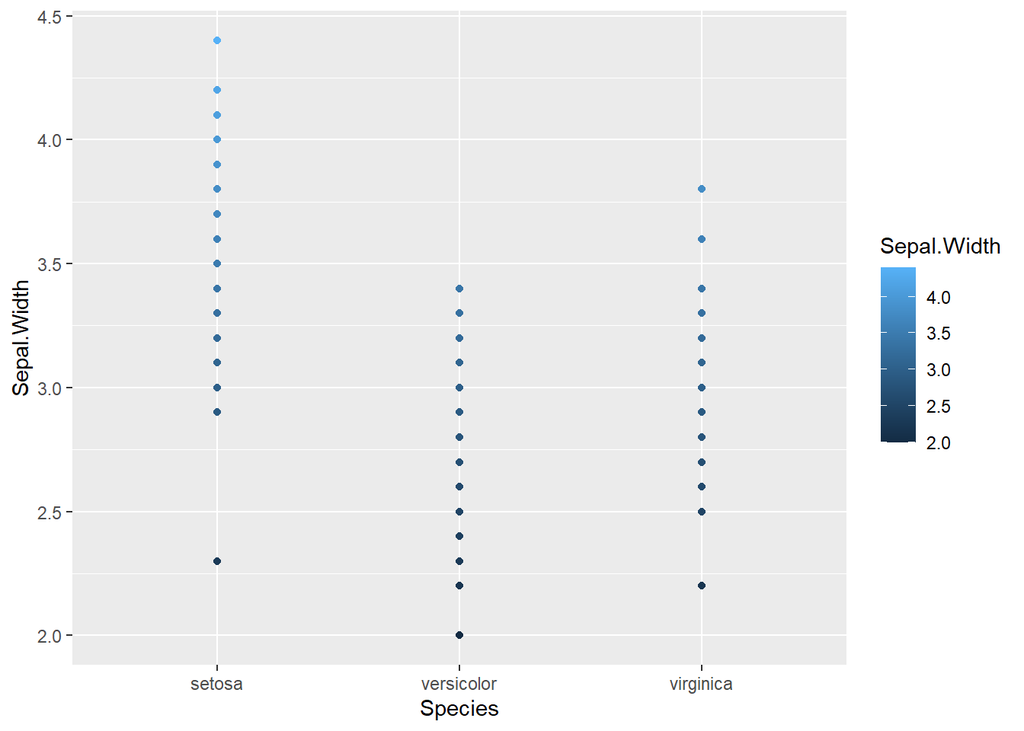

```r
ggplot(iris, aes(color = Sepal.Width,
                 y = Sepal.Width,
                 x = Species)) +
  geom_point()
```

There are many choices for mapping continuous variables.

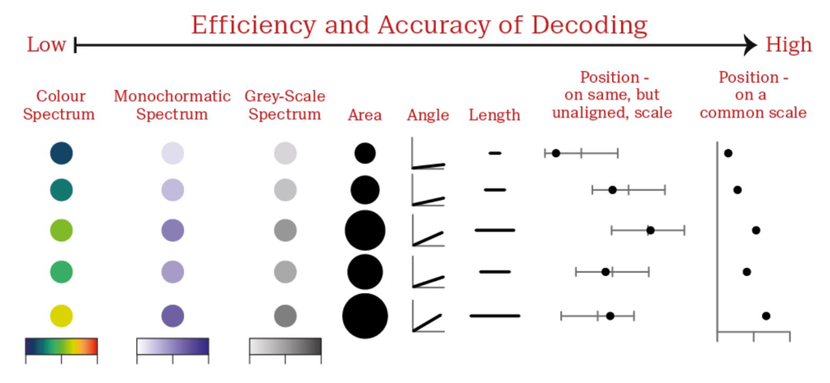

For categorical variables, color is often used for good effect.

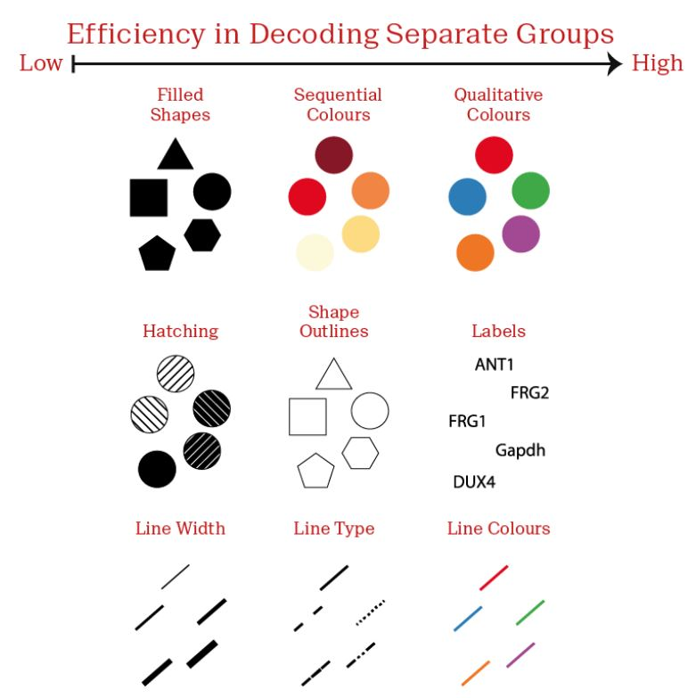